# 管理基準値・ABC計算チュートリアル

# 1. 事前準備

- データの読み込み，RVPA関数の読み込みなど

```r
# 関数の読み込み →
# warningまたは「警告」が出るかもしれませんが，その後動いていれば問題ありません
source("../../rvpa1.9.2.r")
source("../../future2.1.r")
source("../../utilities.r", encoding = "UTF-8")  # ggplotを使ったグラフ作成用の関数

# データの読み込み
caa <- read.csv("caa_pma.csv", row.names = 1)
waa <- read.csv("waa_pma.csv", row.names = 1)
maa <- read.csv("maa_pma.csv", row.names = 1)
dat <- data.handler(caa = caa, waa = waa, maa = maa, M = 0.5)
names(dat)
```

```
[1] "caa"        "maa"        "waa"        "index"      "M"
[6] "maa.tune"   "waa.catch"  "catch.prop"
```

# 2. VPAによる資源量推定

今後はvpa関数の返り値，res.pmaを使って将来予測計算をおこなっていくので，そのためにvpaを実施します．(この辺はあまり詳しく解説しません．)

```r
# VPAによる資源量推定
res.pma <- vpa(dat, fc.year = 2009:2011, rec = 585, rec.year = 2011, tf.year = 2008:2010,
    term.F = "max", stat.tf = "mean", Pope = TRUE, tune = FALSE, p.init = 1)
```

```r
res.pma$Fc.at.age  # 将来予測やMSY計算で使うcurrent F (fc.yearのオプションでいつのFの平均かが指定される)
```

```
        0         1         2         3
0.5436309 1.1766833 1.3059521 1.3059519
```

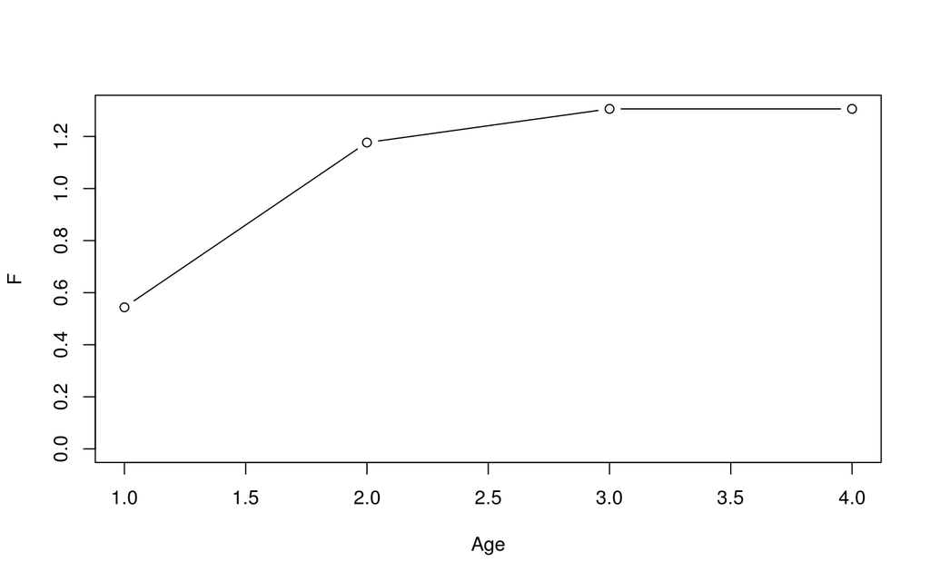

```r
plot(res.pma$Fc.at.age, type = "b", xlab = "Age", ylab = "F", ylim = c(0, max(res.pma$Fc.at.age)))
```

## 2.5 VPA結果を外部から読み込む場合

- read.vpa関数を使って読み込めます
- out.vpa関数による出力と同じ書式になりますので、out.vpa関数でひな形ファイルを作成してから、エクセルでそれを編集し、read.vpa関数で読むと良いと思います

```r
out.vpa(res.pma)  # vpa.csvというファイルが作成されます。VPAの結果のグラフ出力となるvpa.pdfも出力されます。
res.pma2 <- read.vpa("vpa.csv")  # vpa.csvを編集後、read.vpa関数で読み込みます
```

```
Pope is TRUE... OK?
```

# 3. 再生産関係を仮定しない管理基準値の計算

- ref.F関数を使います
- %SPRやFmaxなど、再生産関係を仮定しない管理基準値を計算します
- 計算結果はrres.pmaに格納されます
- YPR, SPR曲線とFcurrent (`res.pma$Fc.at.a`に入っている値です), Fmax, Fmed, F0.1などの位置が表示されます

```r
byear <- 2009:2011 # 生物パラメータを平均する期間を2009年から2011年とする
rres.pma <- ref.F(res.pma, # VPAの計算結果
                  waa.year=byear, maa.year=byear, M.year=byear, # weight at age, maturity at age, Mは2009から2011年までの平均とする
                  rps.year=2000:2011, # Fmedを計算するときに用いるRPSの範囲
                  max.age=Inf, # SPR計算で仮定する年齢の最大値
                  pSPR=c(10,20,30,35,40), # F_%SPRを計算するときに，何パーセントのSPRを計算するか
                  Fspr.init=1)
```

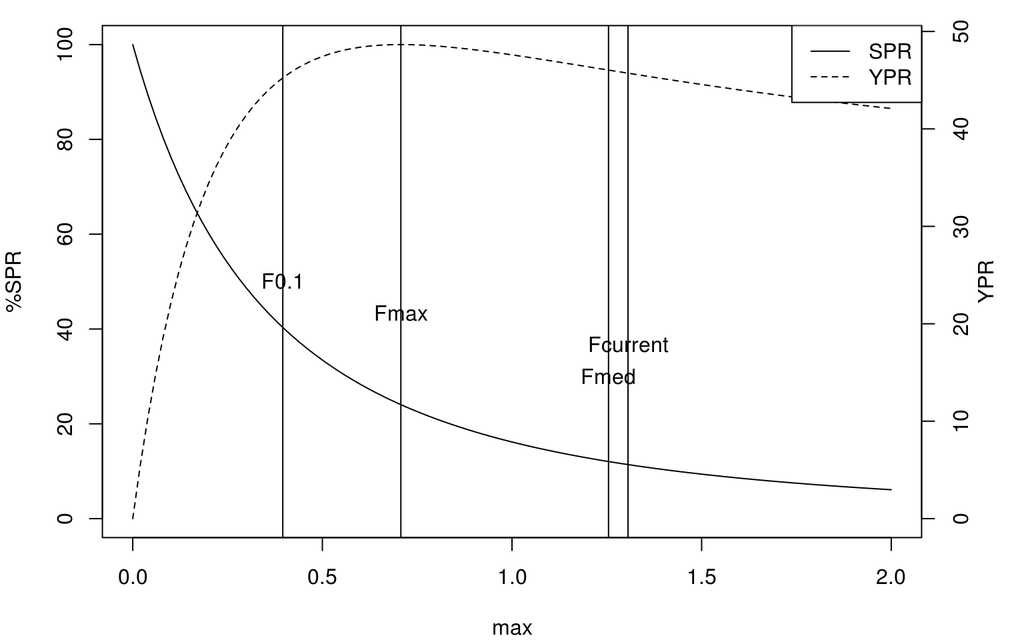

図：YPR, SPR曲線

- 結果のサマリーは`rres.pma$summary`によって見れます
- max: F at ageの最大値，mean: F at ageの平均値，Fref/Fcur: Fcurrentを分母にしたときのF管理基準値の比
- この結果から，現状のF（Fcurrent）はFmedとほぼ同等（Fref/Fcur=0.96なので），F％SRP=10％くらいであることがわかります

```r
rres.pma$summary
```

```
          Fcurrent      Fmed     Flow     Fhigh      Fmax      F0.1
max       1.305952 1.2545205 1.482739 1.0427937 0.7069380 0.3956762
mean      1.083055 1.0404012 1.229668 0.8648116 0.5862791 0.3281429
Fref/Fcur 1.000000 0.9606176 1.135370 0.7984931 0.5413200 0.3029791
              Fmean FpSPR.10.SPR FpSPR.20.SPR FpSPR.30.SPR FpSPR.35.SPR
max       1.2552763     1.434605    0.8363638    0.5648693    0.4739020
mean      1.0410280     1.189749    0.6936147    0.4684585    0.3930172
Fref/Fcur 0.9611963     1.098512    0.6404245    0.4325345    0.3628785
          FpSPR.40.SPR
max          0.4000316
mean         0.3317549
Fref/Fcur    0.3063142
```

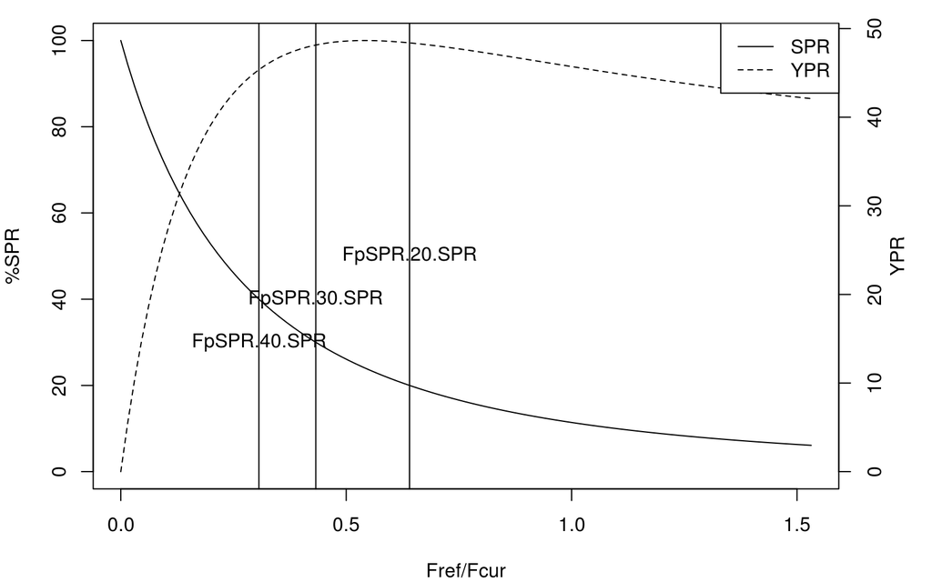

図：YPR, SPR曲線 (x軸などを変更した場合)

```r
# 横軸や縦線で示す管理基準値を調整する場合、plot.Fref関数を使う x.labelは
# res.pma$summaryの行名、vline.textは
# res.pma$summaryの列名前に対応させて指定する
plot.Fref(rres.pma, xlabel = "Fref/Fcur", vline.text = c("FpSPR.20.SPR", "FpSPR.30.SPR",
    "FpSPR.40.SPR"))
```

# 4. 再生産関係の推定

## データの作成

- get.SRdataを使って再生産関係のフィット用のデータを作る
- get.SRdata関数では，`rownames(res.pma$naa)`を参照し、必要な年齢分のSSBをずらしたデータを作成する
- yearは加入年

```r
# VPA結果を使って再生産データを作る
SRdata <- get.SRdata(res.pma)
head(SRdata)
```

```
$year
 [1] 1982 1983 1984 1985 1986 1987 1988 1989 1990 1991 1992 1993 1994 1995
[15] 1996 1997 1998 1999 2000 2001 2002 2003 2004 2005 2006 2007 2008 2009
[29] 2010 2011

$SSB
 [1] 12199.02 15266.68 15072.03 19114.22 23544.42 28769.36 34764.44
 [8] 38219.49 48535.10 61891.08 63966.56 38839.78 53404.29 47322.39
[15] 54485.00 54385.04 47917.14 46090.77 59847.97 53370.62 48781.21
[22] 42719.43 40095.38 39311.72 38335.98 37564.69 27604.88 23079.33
[29] 22902.91 21427.90

$R
 [1]  406.0086  498.9652  544.3007  469.6025 1106.8877 1043.4237  696.7049
 [8]  923.9567 1353.1790 1698.8457 1117.5454 2381.1352 1669.1381 1818.3638
[15] 1858.0043 1458.9524 1334.9288 1116.9433 1100.4598 1693.9770 1090.7181
[22] 1081.8377 1265.0559 1024.0418  753.5207  764.9720  879.6573  513.1128
[29]  570.9195  585.0000
```

```r
# SSBとRのデータだけを持っている場合
SRdata0 <- get.SRdata(R.dat = exp(rnorm(10)), SSB.dat = exp(rnorm(10)))
# 特定の期間のデータだけを使う場合
SRdata0 <- get.SRdata(res.pma, years = 1990:2000)
```

## モデルのフィット

- HS,BH,RIをフィットし，再生産関係のパラメータを推定する
- 結果のオブジェクトのAICcにAICcの値が入っているので，それを比較し，再生産関係を決定する
- SR.fitオプション
  - SR:再生産関係のタイプ： “HS”（ホッケー・スティック）、“BH”（べバートン・ホルト）、“RI”（リッカー）
  - AR: 自己相関の考慮なし(AR=1)、過去１年分の自己相関を考慮(AR=1) （１年分しか対応していない）
  - method: 最小二乗法（“L2”)か最小絶対値法（“L1”）
  - **自己相関あり・なしでAICcを比較し、自己相関を入れたほうがいいかどうか判断する**
    - $\log(R_t)=\log(HS(SSB_t))+\rho \times {\log(R_{t-1})-\log(HS(SSB_{t-1}))}$
    - $\log(R_t)~N(\log(R_t),\sigma^2)$
  - **自己相関パラメータrhoの推定については不安定な部分があります。計算方法の改善により今後値が変わる可能性があります**
  - この例の場合はHSでARなしで最もAICcが小さい→MSY計算ではHS.par0の結果を使う

```r
HS.par0 <- fit.SR(SRdata, SR = "HS", method = "L2", AR = 0, hessian = FALSE)
HS.par1 <- fit.SR(SRdata, SR = "HS", method = "L2", AR = 1, hessian = FALSE)
BH.par0 <- fit.SR(SRdata, SR = "BH", method = "L2", AR = 0, hessian = FALSE)
BH.par1 <- fit.SR(SRdata, SR = "BH", method = "L2", AR = 1, hessian = FALSE)
RI.par0 <- fit.SR(SRdata, SR = "RI", method = "L2", AR = 0, hessian = FALSE)
RI.par1 <- fit.SR(SRdata, SR = "RI", method = "L2", AR = 1, hessian = FALSE)
c(HS.par0$AICc, HS.par1$AICc, BH.par0$AICc, BH.par1$AICc, RI.par0$AICc, RI.par1$AICc)
```

```
[1] 10.66778 13.27672 11.44803 14.11029 11.40670 14.05799
```

- 結果の図示

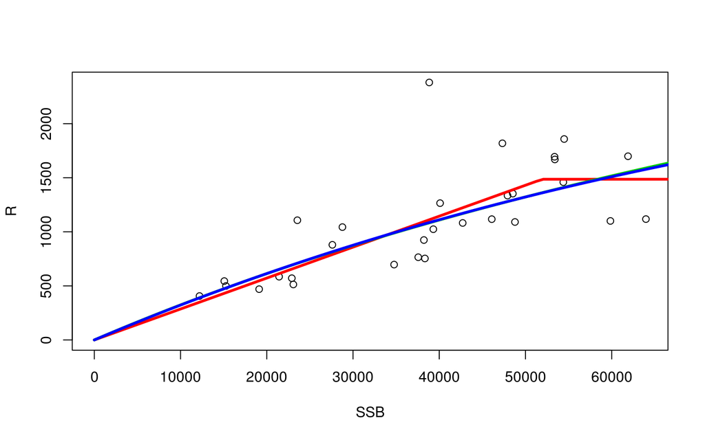

図：**観測値（○）に対する再生産関係式．plot=赤がHS，緑と青がBH, RIだが両者はほとんど重なっていて見えない**

```r
plot.SRdata(SRdata)
lines(HS.par0$pred, col = 2, type = "l", lwd = 3)
lines(BH.par0$pred, col = 3, type = "l", lwd = 3)
lines(RI.par0$pred, col = 4, type = "l", lwd = 3)
```

- TMBオプション(`TMB=TRUE`)も使えます（**ちょっと不安定です。使いたい場合はお問い合わせください**）  
  autoregressiveSR2.cppをダウンロードして，作業フォルダに置く

```r
# install.packages('TMB')　#TMBがインストールされてなければ
library(TMB)
compile("autoregressiveSR2.cpp")
dyn.load(dynlib("autoregressiveSR2"))
HS.par11 <- fit.SR(SRdata, SR = "HS", method = "L2", AR = 1, TMB = TRUE)  #marginal likelihood
```

## モデル診断

再生産関係のあてはめのあとは、推定されたパラメータの信頼区間や頑健性などをチェックする必要があります。そのための関数群なども用意しています。詳しくは [SRRガイドライン](https://ichimomo.github.io/future-rvpa/SRR-guidline.html) へ

# 5. 将来予測

future.vpa関数を使います

- recfuncの引数に再生産関係の関数を，rec.argにrecfuncに対する引数（再生産関係のパラメータ）を入れる
- 利用可能な再生産関数
  - HS.recAR: ホッケー・スティック＋加入は対数正規分布＋自己相関ありの場合も対応
  - RI.recAR・BH.recAR：HS.recARのリッカー・べバートンホルトバージョン
  - HS.rec, BH.rec, RI.rec : 残差リサンプリング用

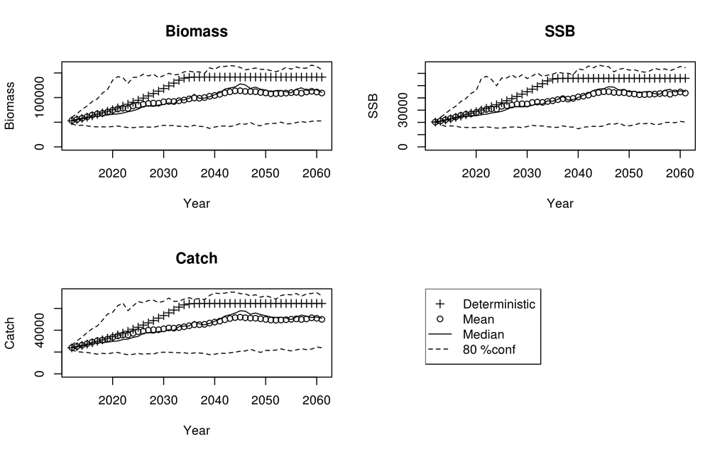

**図：is.plot=TRUEで表示される図．資源量(Biomass)，親魚資源量(SSB), 漁獲量(Catch)の時系列．決定論的将来予測（Deterministic），平均値（Mean），中央値(Median)，80％信頼区間を表示**

```r
fres.HS <- future.vpa(res.pma,
                      multi=1, # res.pma$Fc.at.ageに掛ける乗数
                      nyear=50, # 将来予測の年数
                      start.year=2012, # 将来予測の開始年
                      N=100, # 確率的計算の繰り返し回数
                      ABC.year=2013, # ABCを計算する年
                      waa.year=2009:2011, # 生物パラメータの参照年
                      maa.year=2009:2011,
                      M.year=2009:2011,
                      is.plot=TRUE, # 結果をプロットするかどうか
                      seed=1,
                      silent=TRUE,
                      recfunc=HS.recAR, # 再生産関係の関数
                      # recfuncに対する引数
                      rec.arg=list(a=HS.par0$pars$a,b=HS.par0$pars$b,
                                   rho=HS.par0$pars$rho, # ここではrho=0なので指定しなくてもOK
                                   sd=HS.par0$pars$sd,resid=HS.par0$resid))
```

### 将来予測で自己相関を考慮する場合

```r
fres.HS.AR <- future.vpa(res.pma,
                      multi=1,
                      nyear=50, # 将来予測の年数
                      start.year=2012, # 将来予測の開始年
                      N=100, # 確率的計算の繰り返し回数
                      ABC.year=2013, # ABCを計算する年
                      waa.year=2009:2011, # 生物パラメータの参照年
                      maa.year=2009:2011,
                      M.year=2009:2011,is.plot=FALSE,
                      seed=1, silent=TRUE,recfunc=HS.recAR,
                      # recfuncに対する引数 => 自己相関ありのオプションで計算した結果を入れる
                      rec.arg=list(a=HS.par1$pars$a,b=HS.par1$pars$b,
                                   rho=HS.par1$pars$rho, # 自己相関が高い場合、この値が>0となる
                                   sd=HS.par1$pars$sd,
                                   resid=HS.par1$resid, # 再生産関係における残差の時系列
                                   resid.year=NULL # 近年の残差を何年分平均して将来予測に使うか？NULLの場合は、最後の年の残差を使う
                                   )
                      )
```

### Beverton-Holtを仮定する場合

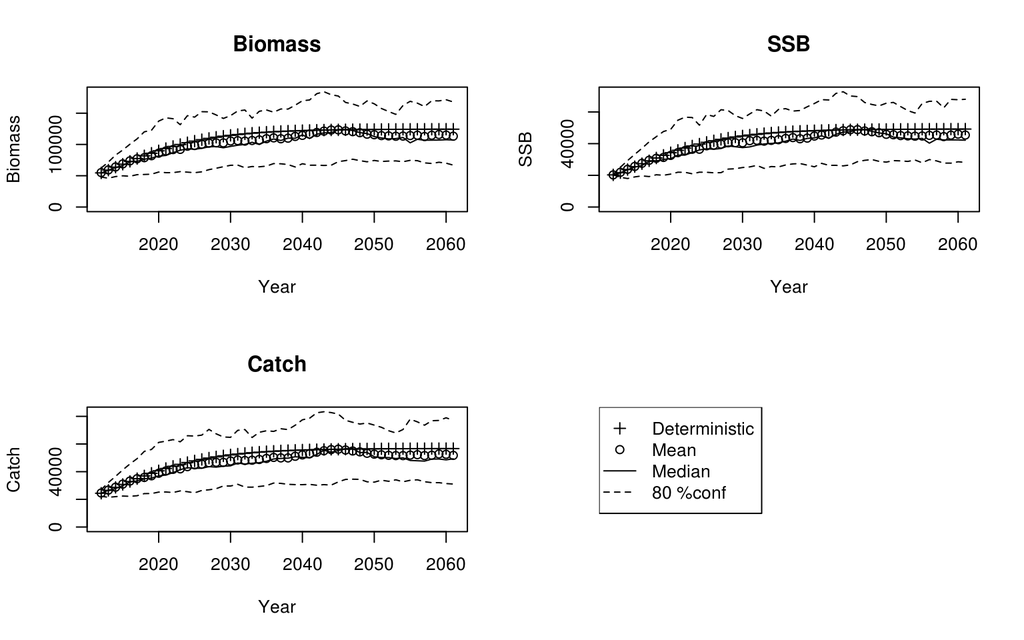

**図：is.plot=TRUEで表示される図．資源量(Biomass)，親魚資源量(SSB), 漁獲量(Catch)の時系列．決定論的将来予測（Deterministic），平均値（Mean），中央値(Median)，80％信頼区間を表示**

```r
fres.BH <- future.vpa(res.pma,
                      multi=1,
                      nyear=50, # 将来予測の年数
                      start.year=2012, # 将来予測の開始年
                      N=100, # 確率的計算の繰り返し回数
                      ABC.year=2013, # ABCを計算する年
                      waa.year=2009:2011, # 生物パラメータの参照年
                      maa.year=2009:2011,
                      M.year=2009:2011,
                      is.plot=TRUE, # 結果をプロットするかどうか
                      seed=1,
                      silent=TRUE,
                      recfunc=BH.recAR, # 再生産関係の関数
                      # recfuncに対する引数
                      rec.arg=list(a=BH.par0$pars$a,b=BH.par0$pars$b,rho=BH.par0$rho,
                                   sd=BH.par0$pars$sd,resid=BH.par0$resid))
```

同じ引数を使ってもう一度将来予測をする

- `fres.HS$input`に、将来予測で使った引数が入っているので、それにdo.call(関数、引数)すると同じ計算を繰り返せる

```r
fres.HS2 <- do.call(future.vpa, fres.HS$input)
```

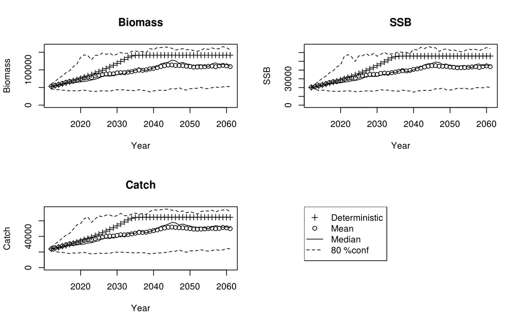

- fres.HS$inputを上書きすることで，同じ引数を使いながら設定を少しだけ変更した将来予測が実行できる
- 引数`multi`がcurrent Fへの乗数になる
- たとえばmulti=1からmulti=0.5に変更する例は以下のとおり

```r
# 引数をinput.tmpに代入．
input.tmp <- fres.HS2$input
# 引数の一部を変える
input.tmp$multi <- 0.5  # current Fの1/2で漁獲
fres.HS3 <- do.call(future.vpa, input.tmp)
```

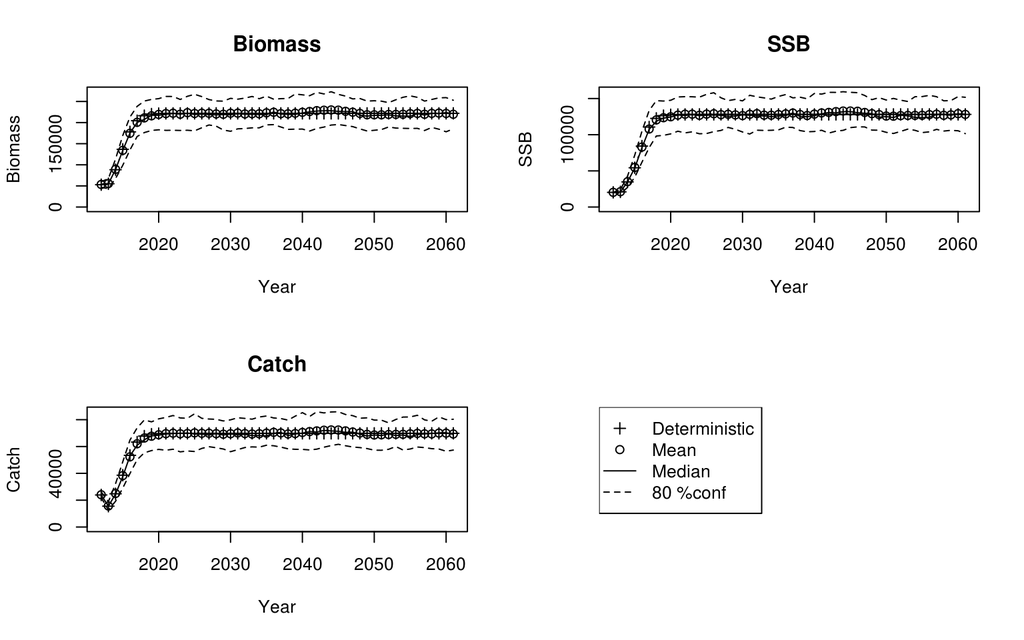

plot.futures関数を使って複数の結果を比較

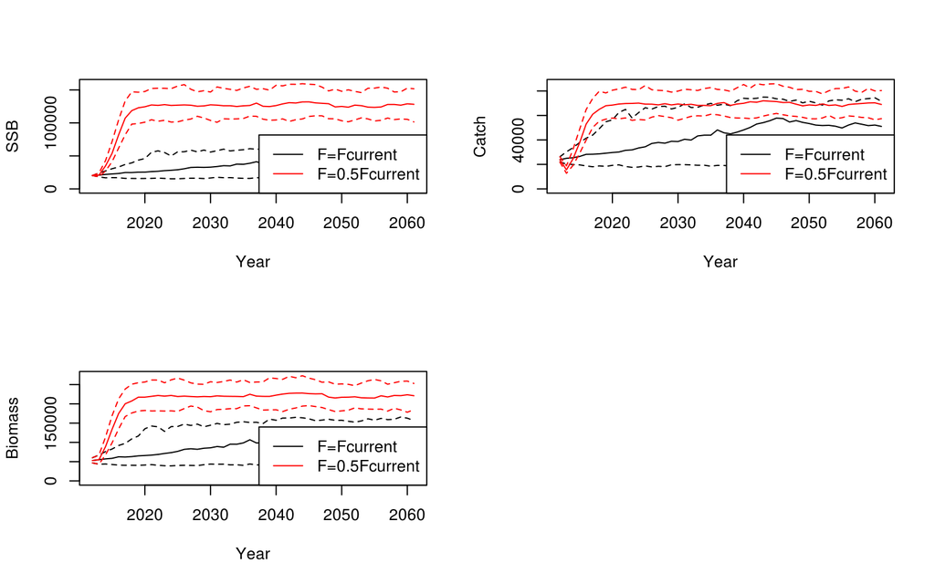

図：plot.futures関数の結果

```r
par(mfrow = c(2, 2))
plot.futures(list(fres.HS, fres.HS3), legend.text = c("F=Fcurrent", "F=0.5Fcurrent"),
    target = "SSB")
plot.futures(list(fres.HS, fres.HS3), legend.text = c("F=Fcurrent", "F=0.5Fcurrent"),
    target = "Catch")
plot.futures(list(fres.HS, fres.HS3), legend.text = c("F=Fcurrent", "F=0.5Fcurrent"),
    target = "Biomass")
```

## (5-1) Fの設定やFrec

将来予測における漁獲のシナリオ

- future.vpaの引数`ABC.year`で指定した年から，Fcurrent × multiによるFで漁獲される
- ABC.year-1年まではFcurrentによる漁獲
- *Frecに引数を与えることで，任意の資源量に任意の確率で回復させるような将来予測ができます．*

**Frecのオプション**

| オプション | 説明 |
| --- | --- |
| stochastic | 確率的将来予測をもとにFrecを計算するかどうか |
| future.year | 条件を満たしているかどうかを判断する年 |
| Blimit | 条件として使われる閾値 |
| scenario | =“blimit”: Blimitを**下回る**確率をtarget.probsにする |
|  | =“catch.mean”: future.year年の平均漁獲量をBlimitの値と一致させる |
|  | =“ssb.mean”: future.year年の平均親魚量をBlimitの値と一致させる |
| target.probs | scenario=“blimit”のときに目的とする確率（パーセントで指定） |
| Frange | 探索するFの範囲．指定しない場合，c(0.01,multi*2)の範囲で探索しますので，うまく推定できない場合はfuture.vpaの引数multiを変えるか，このオプションでそれらしいFの値に限定してください\| |

[output not shown]

[output cut: 100 more lines]

[output not shown]

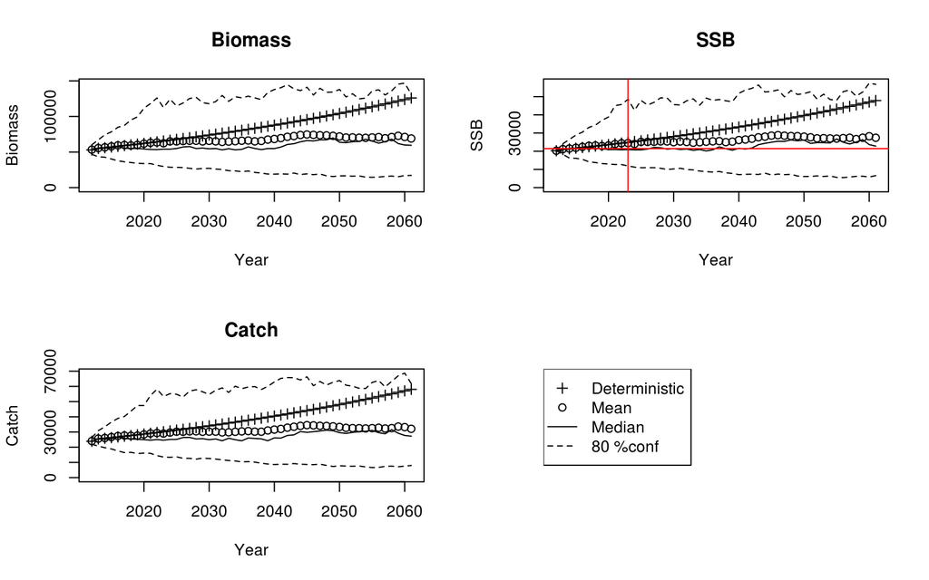

Frecオプションを使った場合は、結果の図に目的とする年・資源量のところに赤線が入ります。これが将来予測の結果と一致しているか確かめてください。もし一致していない場合、multi（初期値）かFrecのオプションのFrangeを指定してやり直してください

```r
# たとえば現状の資源量に維持するシナリオ
fres.currentSSB <- future.vpa(res.pma,
                      multi=0.8,
                      nyear=50, # 将来予測の年数
                      start.year=2012, # 将来予測の開始年
                      N=100, # 確率的計算の繰り返し回数
                      ABC.year=2013, # ABCを計算する年
                      waa.year=2009:2011, # 生物パラメータの参照年
                      maa.year=2009:2011,
                      M.year=2009:2011,seed=1,
                      is.plot=TRUE, # 結果をプロットするかどうか
                      Frec=list(stochastic=TRUE,future.year=2023,Blimit=rev(colSums(res.pma$ssb))[1],scenario="blimit",target.probs=50),
                      recfunc=HS.recAR, # 再生産関係の関数
                      # recfuncに対する引数
                      rec.arg=list(a=HS.par0$pars$a,b=HS.par0$pars$b,
                                   rho=HS.par0$pars$rho,
                                   sd=HS.par0$pars$sd,bias.corrected=TRUE))
```

## (5-2) 再生産関係

- 残差リサンプリングで将来予測をする場合→refuncとしてHS.rec（ホッケー・スティック）、BH.rec（べバートン・ホルト）、RI.rec（リッカー）を使う
- rec.argの引数で、**必ず** resample=TRUEとしてください。
- rho>0の場合には対応しておりません

[output not shown]

[output cut: 108 more lines]

[output not shown]

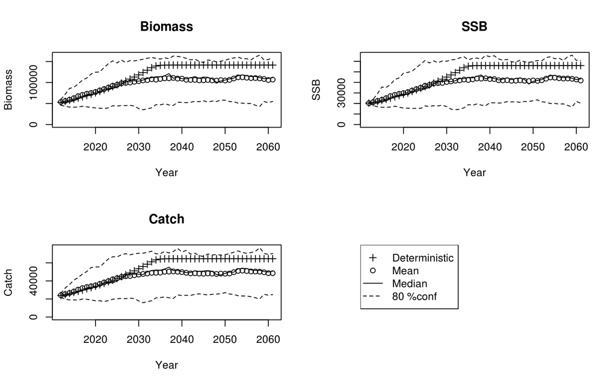

```r
# 残差リサンプリングによる将来予測
fres.HS4 <- future.vpa(res.pma,
                          multi=1,
                          nyear=50, # 将来予測の年数
                          start.year=2012, # 将来予測の開始年
                          N=100, # 確率的計算の繰り返し回数
                          ABC.year=2013, # ABCを計算する年
                          waa.year=2009:2011, # 生物パラメータの参照年
                          maa.year=2009:2011,
                          M.year=2009:2011,
                          is.plot=TRUE, # 結果をプロットするかどうか
                          seed=1,
                          recfunc=HS.rec, # 再生産関係の関数（HS.rec=Hockey-stick)
                          rec.arg=list(a=HS.par0$pars$a,b=HS.par0$pars$b,
                                       rho=HS.par0$pars$rho,
                                       sd=HS.par0$pars$sd,bias.correction=TRUE,
                                       resample=TRUE,resid=HS.par0$resid))
```

残差リサンプリングか対数正規分布かの違いを比較

```r
par(mfrow = c(2, 2))
plot(fres.HS$vssb[, -1], fres.HS$naa[1, , -1], xlab = "SSB", ylab = "Recruits")
plot(fres.HS4$vssb[, -1], fres.HS4$naa[1, , -1], xlab = "SSB", ylab = "Recruits")
plot.futures(list(fres.HS, fres.HS4))  # 両者の比較
```

[output not shown]

## (5-3) 年齢別体重が資源尾数に影響される場合の将来予測

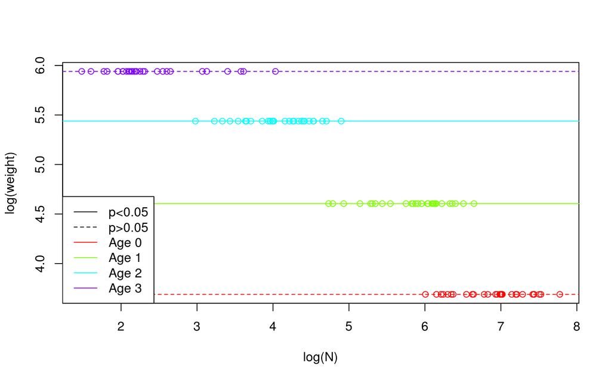

```r
lm.res <- plot.waa(res.pma)  # weight at ageが資源尾数の関数になっているかどうか，確認してみる．この例の場合は特に有意な関係はない
```

```r
# lm.resの中に回帰した結果が年齢分だけ入っています
fres.HS6 <- fres.HS
fres.HS6$input$waa.fun <- TRUE
fres.HS6$input$N <- 1000
fres.HS6 <- do.call(future.vpa, fres.HS6$input)
```

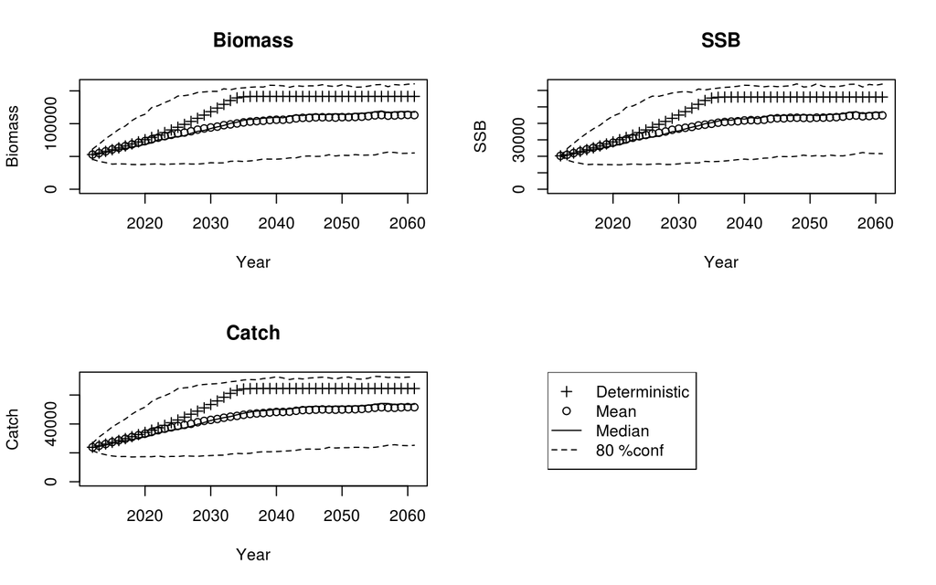

## (5-4) その他のオプション

- `HCR=list(Blim=154500, Bban=49400,beta=1)` のように与えると、BlimからBbanまで直線的にFが減少するようなHCRで漁獲します。betaは、全体のFに掛ける乗数です。
- `pre.catch=list(year=2013,wcatch=13000)`のように与えると特定の年の漁獲量をwcatchで与えた漁獲量で固定します
- `rec.new=list(year=2012,rec=1500)`のように与えると、対応する年の加入を置き換えます。

```r
# 残差リサンプリングによる将来予測
fres.HS5 <- future.vpa(res.pma,
                       multi=1,
                       nyear=50, # 将来予測の年数
                       start.year=2012, # 将来予測の開始年
                       N=100, # 確率的計算の繰り返し回数
                       ABC.year=2013, # ABCを計算する年
                       waa.year=2009:2011, # 生物パラメータの参照年
                       maa.year=2009:2011,
                       M.year=2009:2011,
                       recfunc=HS.rec,
                       rec.arg=list(a=HS.par0$pars$a,b=HS.par0$pars$b,
                                       rho=HS.par0$pars$rho,
                                       sd=HS.par0$pars$sd,bias.correction=TRUE,
                                    resample=TRUE,resid=HS.par0$resid),
                       rec.new=list(year=2012,rec=100),
                       pre.catch=list(year=2013,wcatch=100)
                       )
```

[output not shown]

[output cut: 119 more lines]

[output not shown]

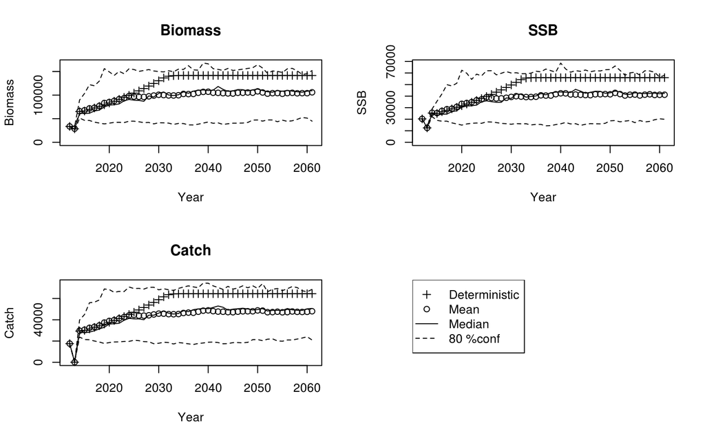

# 6. MSY管理基準値の計算

- MSY管理基準値計算では，上記の将来予測において，Fの値を様々に変えたときの平衡状態（世代時間×20年を`nyear`で指定します）における資源量やそれに対応するF等を管理基準値として算出します
- なので、ここまでのプロセスで、ABC計算のためにきちんとしたオプションを設定したfuture.vpaを実行しておいてください。その返り値`fres.HS`をMSY計算では使っていきます

## est.MSYの説明

- この関数で計算できる管理基準値は以下のようなものになります
- どの管理基準値がtarget, limit, banになるかは関数内では評価されません

| est.MSYの引数（重要なもののみ） | 説明 |
| --- | --- |
| vpares | VPA結果のオブジェクト |
| farg | 将来予測関数future.vpaへの引数のリスト。通常はfuture.vpaを実施したあとのオブジェクトがfoutだった場合、fout$inputと指定すれば良いです |
| trace.multi | Fmsyを探索したり、Yield curveを書くときにグリッドサーチをするときのFの刻み。Fcurrentに対する乗数。Fが異常に大きい場合、親魚=0になって加入＝NAとなるので現実的な値を入れる |
| long.term | 世代時間の何倍年後の状態を平衡状態と仮定するか |
| mY | 自己相関を考慮して管理基準値を計算する場合、平衡状態から何年分進めたときの資源量を管理基準値として使うか |
| resid.year | ARありの場合、最近何年分の残差を平均するかをここで指定する。ARありの設定を反映させたい場合必ずここを１以上とすること（とりあえず１としておいてください）。 |
| current.resid | 残差の値を直接入れる場合。上の年数が設定されていてもこちらが設定されたらこの値を使う |
| PGY | MSYの何割の平均漁獲量を得るときの親魚資源量を管理基準値として推定するか。比率で入力する |
| B0percent | F=0のときの平均親魚資源量の一定割合に相当する親魚量を管理基準値として推定するか。比率で入力する |
| Bempirical | 現行の親魚資源量、HSの折れ点など、特定の親魚資源量で平衡状態になるとしたときの管理基準値。親魚資源量の絶対値で与える。 |

| 管理基準値 | 説明 |
| --- | --- |
| SSB_MSY | 平衡状態において平均最大漁獲量が最大になるときの親魚量 |
| SSB_0 (XX%) | F=0で将来予測したときの平衡状態における親魚量($B_0$)に対する割合（引数`B0percent`でc(0.4, 0.5)のように指定します） |
| SSB_PGY (LXX%) (HXX%) | SS_MSYで達成される漁獲量のXX%を達成するときの親魚量の下限または上限（引数`PGY`でc(0.9, 0.95)のように指定します） |
| SSB_empirical | 過去最大・最小漁獲量、など、経験的な親魚資源量の値 |

[output not shown]

*1: summaryまたはsummaryARのFref/Fcurrentが現行のFからのFの削減率になります（（Fref/Fcurrent-1)×100が資源評価票の要約表の「現状のF値からの増減％」に相当します）。この値にさらにβ（Btargetを上回る確率が５０％かつBlimitを上回る確率が９０％以上になるように調整する係数）と(B-Bban)/(Blim-Bban)を乗じたFをもとにABCが算定されます

```r
# MSY管理基準値の計算
MSY.HS <- est.MSY(res.pma, # VPAの計算結果
                 fres.HS$input, # 将来予測で使用した引数
#                 nyear=NULL, # 何年計算するかは、指定しなければ関数内部で世代時間の20倍の年数を計算し、それを平衡状態とする
                 resid.year=0, # ARありの場合、最近何年分の残差を平均するかをここで指定する。ARありの設定を反映させたい場合必ずここを１以上とすること（とりあえず１としておいてください）。
                 N=100, # 将来予測の年数，繰り返し回数
                 PGY=c(0.9,0.6,0.1), # 計算したいPGYレベル。上限と下限の両方が計算される
                 onlylower.pgy=FALSE, # TRUEにするとPGYレベルの上限は計算しない（計算時間の節約になる）
                 B0percent=c(0.3,0.4)) # 計算したいB0%レベル
```

```
Estimating MSY
F multiplier= 0.523244
Estimating PGY  90 %
F multiplier= 0.2633456
F multiplier= 0.9540607
Estimating PGY  60 %
F multiplier= 0.1131719
F multiplier= 1.019431
Estimating PGY  10 %
F multiplier= 0.01319282
F multiplier= 1.079894
Estimating B0  30 %
F multiplier= 0.4342835
Estimating B0  40 %
F multiplier= 0.3071907
```

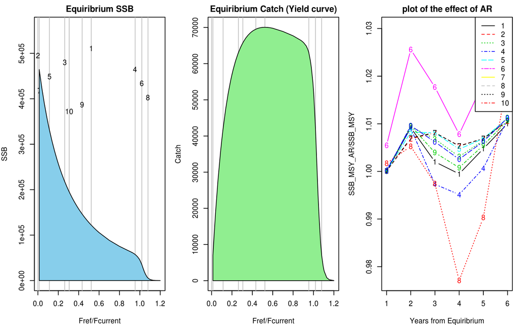

```r
# 結果の表示(tibbleという形式で表示され、最初の10行以外は省略されます)
(refs.all <- MSY.HS$summary_tb)
```

```
# A tibble: 20 x 15
   RP_name AR       SSB SSB2SSB0      B      U  Catch Catch.CV `Fref/Fcur`
   <chr>   <lgl>  <dbl>    <dbl>  <dbl>  <dbl>  <dbl>    <dbl>       <dbl>
 1 MSY     FALSE 1.22e5   0.250  2.16e5 0.324  70056.   0.136       0.523
 2 B0      FALSE 4.88e5   1      5.94e5 0          0  NaN           0
 3 PGY_0.… FALSE 2.18e5   0.446  3.17e5 0.199  63051.   0.119       0.263
 4 PGY_0.… FALSE 5.74e4   0.118  1.41e5 0.447  63052.   0.181       0.954
 5 PGY_0.… FALSE 3.31e5   0.680  4.34e5 0.0968 42034.   0.106       0.113
 6 PGY_0.… FALSE 3.52e4   0.0721 9.18e4 0.458  42054.   0.470       1.02
 7 PGY_0.… FALSE 4.64e5   0.952  5.70e5 0.0123  7001.   0.0963      0.0132
 8 PGY_0.… FALSE 5.53e3   0.0113 1.49e4 0.471   7008.   1.42        1.08
 9 B0-30%  FALSE 1.46e5   0.300  2.42e5 0.287  69534.   0.131       0.434
10 B0-40%  FALSE 1.95e5   0.400  2.94e5 0.224  65777.   0.122       0.307
11 MSY     TRUE  1.23e5   0.250  2.16e5 0.325  70210.   0.141       0.523
12 B0      TRUE  4.93e5   1      5.97e5 0          0  NaN           0
13 PGY_0.… TRUE  2.20e5   0.446  3.18e5 0.199  63416.   0.122       0.263
14 PGY_0.… TRUE  5.80e4   0.118  1.41e5 0.448  63031.   0.198       0.954
15 PGY_0.… TRUE  3.35e5   0.680  4.37e5 0.0969 42338.   0.109       0.113
16 PGY_0.… TRUE  3.61e4   0.0721 9.30e4 0.459  42704.   0.481       1.02
17 PGY_0.… TRUE  4.69e5   0.952  5.73e5 0.0123  7055.   0.101       0.0132
18 PGY_0.… TRUE  5.64e3   0.0113 1.54e4 0.469   7235.   1.70        1.08
19 B0-30%  TRUE  1.48e5   0.300  2.43e5 0.288  69779.   0.135       0.434
20 B0-40%  TRUE  1.97e5   0.400  2.95e5 0.224  66123.   0.125       0.307
# ... with 6 more variables: Fref2Fcurrent <dbl>, F0 <dbl>, F1 <dbl>,
#   F2 <dbl>, F3 <dbl>, RP.definition <chr>
```

```r
# 全データをじっくり見たい場合
View(refs.all)

# のちの使用のために、Bmsy, Blimit, Bban, Fmsyを定義しておく
refs <- list(BmsyAR=as.numeric(MSY.HS$summaryAR$SSB[1]),
             BlimAR=as.numeric(MSY.HS$summaryAR$SSB[6]),
             BbanAR=as.numeric(MSY.HS$summaryAR$SSB[8]),
             Bmsy=as.numeric(MSY.HS$summary$SSB[1]),
             Blim=as.numeric(MSY.HS$summary$SSB[6]),
             Bban=as.numeric(MSY.HS$summary$SSB[8]),
             Fmsy=as.numeric(MSY.HS$summary$"Fref/Fcur"[1]),
             MSY=as.numeric(MSY.HS$summary$Catch[1]),
             Umsy=as.numeric(MSY.HS$summary$Catch[1])/as.numeric(MSY.HS$all.stat$biom.mean[1]))

# また、各管理基準値に対して以下のようなラベルをつける
# どの管理基準値をどのように定義するか、ここで指定します
refs.all$RP.definition <- NA
refs.all$RP.definition[refs.all$RP_name=="MSY" & refs.all$AR==FALSE] <- "Btarget0"  # RP_nameがMSYでARがなしのものをBtargetとする
refs.all$RP.definition[refs.all$RP_name=="B0-20%" & refs.all$AR==FALSE] <- "Btarget1"  # たとえばBtargetの代替値をいちおう示す場合
refs.all$RP.definition[refs.all$RP_name=="PGY_0.95_lower" & refs.all$AR==FALSE] <- "Btarget2"
refs.all$RP.definition[refs.all$RP_name=="PGY_0.9_lower" & refs.all$AR==FALSE] <- "Blow0"
refs.all$RP.definition[refs.all$RP_name=="PGY_0.6_lower" & refs.all$AR==FALSE] <- "Blimit0"
refs.all$RP.definition[refs.all$RP_name=="PGY_0.1_lower" & refs.all$AR==FALSE] <- "Bban0"
refs.all$RP.definition[refs.all$RP_name=="Ben-19431" & refs.all$AR==FALSE] <- "Bcurrent"
refs.all$RP.definition[refs.all$RP_name=="Ben-63967" & refs.all$AR==FALSE] <- "Bmax"
refs.all$RP.definition[refs.all$RP_name=="Ben-24000" & refs.all$AR==FALSE] <- "Blimit1"
refs.all$RP.definition[refs.all$RP_name=="Ben-51882" & refs.all$AR==FALSE] <- "B_HS"

# 定義した結果を見る
refs.all %>% select(RP_name,RP.definition)
```

```
# A tibble: 20 x 2
   RP_name       RP.definition
   <chr>         <chr>
 1 MSY           Btarget0
 2 B0            <NA>
 3 PGY_0.9_upper <NA>
 4 PGY_0.9_lower Blow0
 5 PGY_0.6_upper <NA>
 6 PGY_0.6_lower Blimit0
 7 PGY_0.1_upper <NA>
 8 PGY_0.1_lower Bban0
 9 B0-30%        <NA>
10 B0-40%        <NA>
11 MSY           <NA>
12 B0            <NA>
13 PGY_0.9_upper <NA>
14 PGY_0.9_lower <NA>
15 PGY_0.6_upper <NA>
16 PGY_0.6_lower <NA>
17 PGY_0.1_upper <NA>
18 PGY_0.1_lower <NA>
19 B0-30%        <NA>
20 B0-40%        <NA>
```

```r
# refs.allの中からRP.definitionで指定された行だけを抜き出す
(refs.base <- refs.all %>%
    filter(!is.na(RP.definition)) %>% # RP.definitionがNAでないものを抽出
    arrange(desc(SSB)) %>% # SSBを大きい順に並び替え
    select(RP.definition,RP_name,SSB,Catch,U,Fref2Fcurrent)) #　列を並び替え
```

```
# A tibble: 4 x 6
  RP.definition RP_name           SSB  Catch     U Fref2Fcurrent
  <chr>         <chr>           <dbl>  <dbl> <dbl>         <dbl>
1 Btarget0      MSY           122092. 70056. 0.324         0.523
2 Blow0         PGY_0.9_lower  57416. 63052. 0.447         0.954
3 Blimit0       PGY_0.6_lower  35186. 42054. 0.458         1.02
4 Bban0         PGY_0.1_lower   5534.  7008. 0.471         1.08
```

# 7. HCRをもとにした将来予測とABC計算

- 決定された管理基準値のもとで将来予測計算をおこないます
- 資源評価最終年＋２年目の「平均」漁獲量をABCとします
- そのときに用いる親魚資源量は資源評価最終年＋２年目の親魚資源量です

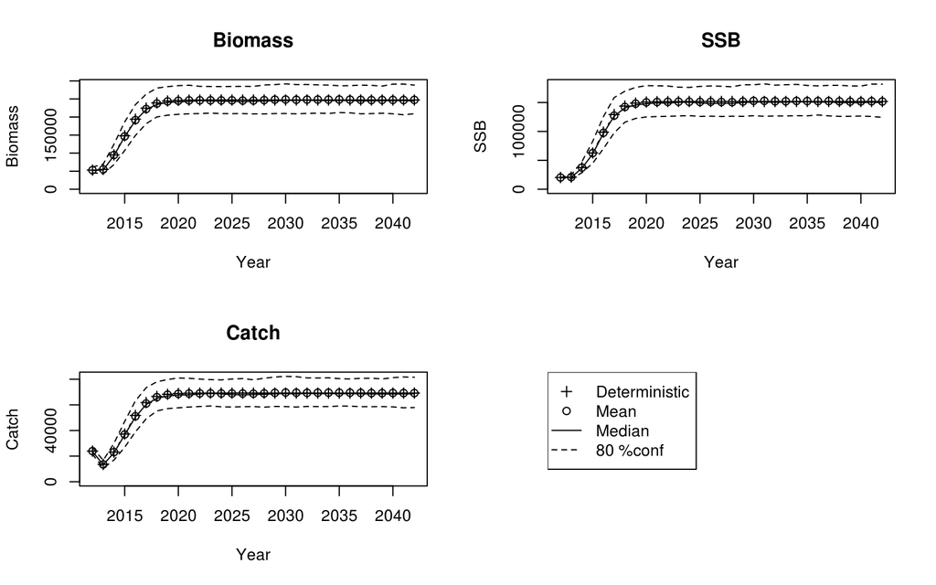

```r
input.abc <- MSY.HS$input$msy  # MSY計算で使った引数を使う
input.abc$N <- 1000  # 実際に計算するときは10000以上を使ってください
input.abc$HCR <- list(Blim = refs$Blim, Bban = refs$Bban, beta = 0.8)  # 算定ルールのデフォルトは0.8
input.abc$nyear <- 30  # ABC計算時には長期間計算する必要はない
input.abc$ABC.year <- 2013  # ここでABC.yearを設定しなおしてください
input.abc$is.plot <- TRUE
fres.abc1 <- do.call(future.vpa, input.abc)
```

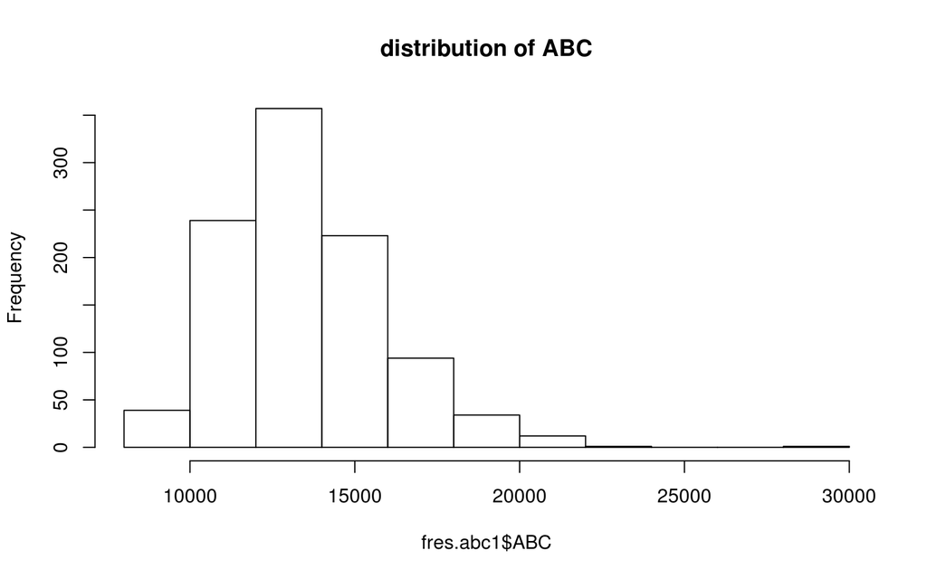

```r
par(mfrow = c(1, 1))
hist(fres.abc1$ABC, main = "distribution of ABC")  # ABCの分布
```

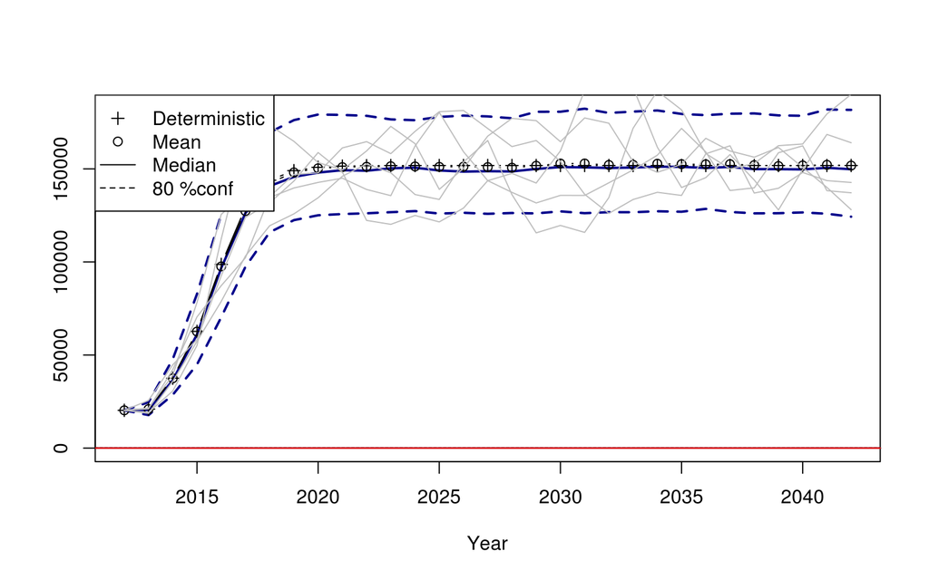

```r
ABC <- mean(fres.abc1$ABC)  # 平均値をABCとする

## SSBの将来予測結果
par(mfrow = c(1, 1))
plot.future(fres.abc1, what = c(FALSE, TRUE, FALSE), is.legend = TRUE, lwd = 2,
    col = "darkblue", N = 5, label = rep(NA, 3))
draw.refline(cbind(unlist(refs[c(1, 1, 2, 3) + 3]), unlist(refs[c(1, 1, 2, 3)])),
    horiz = TRUE, lwd = 1, scale = 1)
```

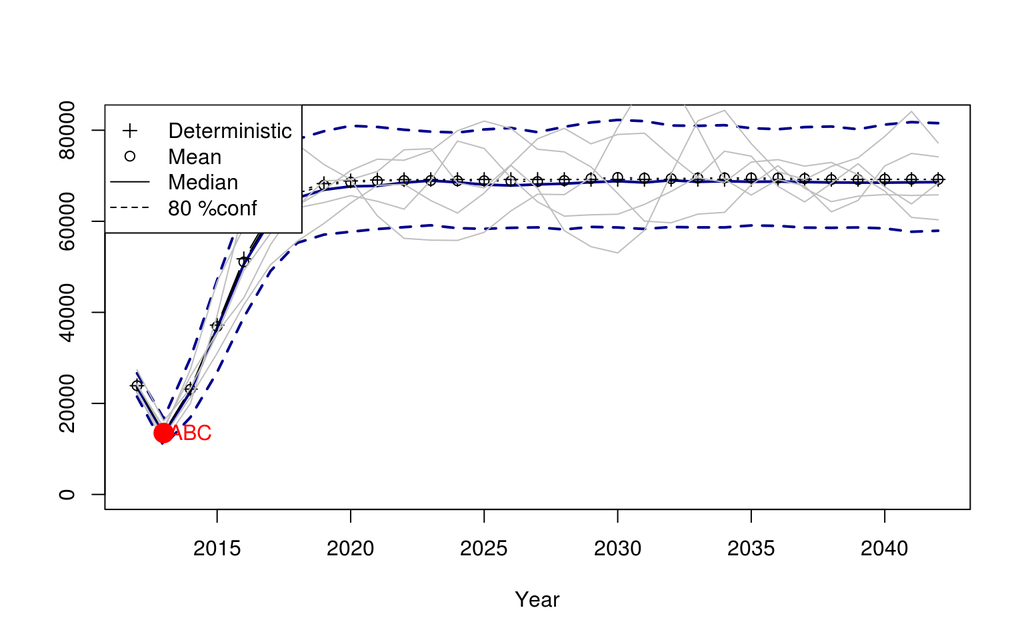

```r
## 漁獲量の将来予測結果
par(mfrow = c(1, 1))
plot.future(fres.abc1, what = c(FALSE, FALSE, TRUE), is.legend = TRUE, lwd = 2,
    col = "darkblue", N = 5, label = rep(NA, 3))
points(fres.abc1$input$ABC.year, ABC, pch = 20, col = 2, cex = 3)
text(fres.abc1$input$ABC.year + 1, ABC, "ABC", col = 2)
```

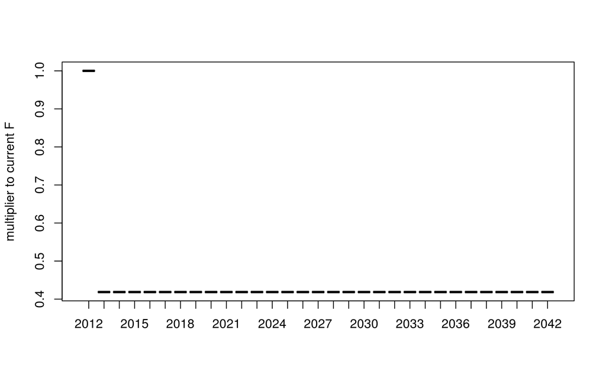

```r
## 実際に、どんなFが将来予測で使われているか
boxplot(t(fres.abc1$faa[1, , ]/fres.abc1$faa[1, 1, ]), ylab = "multiplier to current F")
```

[figure not shown]

```r
# どんなHCRなのか書いてみる
ssb.abc <- mean(fres.abc1$vssb[rownames(fres.abc1$vssb) %in% fres.abc1$input$ABC.year,
    ])  # ABC計算年のssbをとる
plot.HCR(beta = beta, bban = refs$Bban, blimit = refs$Blim, btarget = refs$Bmsy,
    lwd = 2, xlim = c(0, refs$Bmsy * 2), ssb.cur = ssb.abc, Fmsy = refs$Fmsy,
    yscale = 0.7, scale = 1000)
```

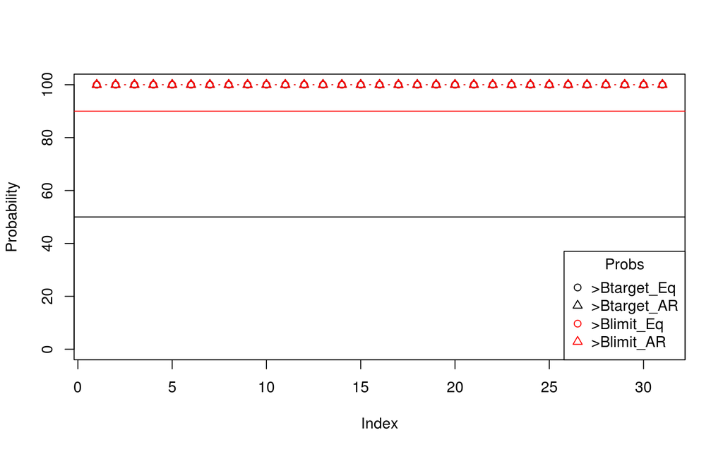

```r
# 将来の親魚資源量がBMSYやBlimitを上回る確率の表示
plot(apply(fres.abc1$vssb > refs$Bmsy, 1, mean) * 100, type = "b", ylab = "Probability",
    ylim = c(0, 100))
points(apply(fres.abc1$vssb > refs$BmsyAR, 1, mean) * 100, pch = 2, type = "b")
points(apply(fres.abc1$vssb > refs$Blim, 1, mean) * 100, pch = 1, col = 2, type = "b")
points(apply(fres.abc1$vssb > refs$BlimAR, 1, mean) * 100, pch = 2, col = 2,
    type = "b")
abline(h = c(50, 90), col = c(1, 2))
legend("bottomright", col = c(1, 1, 2, 2), title = "Probs", pch = c(1, 2, 1,
    2), legend = c(">Btarget_Eq", ">Btarget_AR", ">Blimit_Eq", ">Blimit_AR"))
```

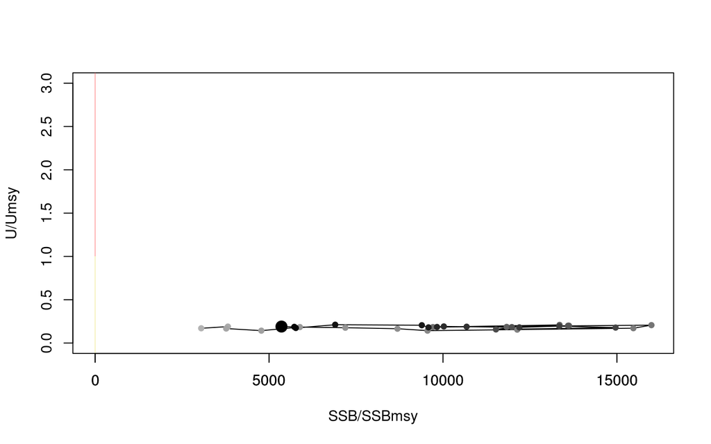

```r
# Kobe chart
plot.kobe(res.pma, Bmsy = refs$Bmsy, Umsy = refs$Umsy, Blim = refs$Blim)
```

# 8. ABC計算までのまとめ（時間がない人はここからスタート）

MSY管理基準値を計算は以下の手順でおこないます．

1. データの読み込み

```r
# 関数の読み込み →
# warningまたは「警告」が出るかもしれませんが，その後動いていれば問題ありません
source("../../rvpa1.9.2.r")
source("../../future2.1.r")
source("../../utilities.r", encoding = "UTF-8")  # ggplotを使ったグラフ作成用の関数

# データの読み込み
caa <- read.csv("caa_pma.csv", row.names = 1)
waa <- read.csv("waa_pma.csv", row.names = 1)
maa <- read.csv("maa_pma.csv", row.names = 1)
dat <- data.handler(caa = caa, waa = waa, maa = maa, M = 0.5)
names(dat)
```

2. VPAの実施(vpa) → res.pma(VPAの結果)を得る
- current Fとしてどのような値を使うか、ここで設定しておく（fc.yearオプションで、何年から何年のFを平均するか指定)

```r
# VPAによる資源量推定
res.pma <- vpa(dat, fc.year = 2009:2011, rec = 585, rec.year = 2011, tf.year = 2008:2010,
    term.F = "max", stat.tf = "mean", Pope = TRUE, tune = FALSE, p.init = 1)
```

3. 再生産関係パラメータのあてはめ (fit.SR) → HS.par0 (HSにあてはめたときのパラメータ推定結果)を得る
- 残差の自己相関がある・なしを決める。ある場合はAR=1としたときの結果を用います。

```r
# VPA結果を使って再生産データを作る
SRdata <- get.SRdata(res.pma)
head(SRdata)
```

```r
HS.par0 <- fit.SR(SRdata, SR = "HS", method = "L2", AR = 0, hessian = FALSE)
HS.par1 <- fit.SR(SRdata, SR = "HS", method = "L2", AR = 1, hessian = FALSE)
BH.par0 <- fit.SR(SRdata, SR = "BH", method = "L2", AR = 0, hessian = FALSE)
BH.par1 <- fit.SR(SRdata, SR = "BH", method = "L2", AR = 1, hessian = FALSE)
RI.par0 <- fit.SR(SRdata, SR = "RI", method = "L2", AR = 0, hessian = FALSE)
RI.par1 <- fit.SR(SRdata, SR = "RI", method = "L2", AR = 1, hessian = FALSE)
c(HS.par0$AICc, HS.par1$AICc, BH.par0$AICc, BH.par1$AICc, RI.par0$AICc, RI.par1$AICc)
```

4. HS.par0をもとに将来予測を実施する(future.vpa) → fres.HS (HSを仮定したときの将来予測結果)を得る
- 生物パラメータを平均する年,ABC計算年などのオプションを設定
- 資源量と年齢別の体重に相関がある場合はそれを将来予測の設定に取り込む(waa.fun=TRUE)

```r
fres.HS <- future.vpa(res.pma,
                      multi=1, # res.pma$Fc.at.ageに掛ける乗数
                      nyear=50, # 将来予測の年数
                      start.year=2012, # 将来予測の開始年
                      N=100, # 確率的計算の繰り返し回数
                      ABC.year=2013, # ABCを計算する年
                      waa.year=2009:2011, # 生物パラメータの参照年
                      maa.year=2009:2011,
                      M.year=2009:2011,
                      is.plot=TRUE, # 結果をプロットするかどうか
                      seed=1,
                      silent=TRUE,
                      recfunc=HS.recAR, # 再生産関係の関数
                      # recfuncに対する引数
                      rec.arg=list(a=HS.par0$pars$a,b=HS.par0$pars$b,
                                   rho=HS.par0$pars$rho, # ここではrho=0なので指定しなくてもOK
                                   sd=HS.par0$pars$sd,resid=HS.par0$resid))
```

5. res.pmaとfres.HSを使ってMSY管理基準値を計算する (est.MSY) → MSY.HS (管理基準値の推定結果)を得る

```r
# MSY管理基準値の計算
MSY.HS <- est.MSY(res.pma, # VPAの計算結果
                 fres.HS$input, # 将来予測で使用した引数
#                 nyear=NULL, # 何年計算するかは、指定しなければ関数内部で世代時間の20倍の年数を計算し、それを平衡状態とする
                 resid.year=0, # ARありの場合、最近何年分の残差を平均するかをここで指定する。ARありの設定を反映させたい場合必ずここを１以上とすること（とりあえず１としておいてください）。
                 N=100, # 将来予測の年数，繰り返し回数
                 PGY=c(0.9,0.6,0.1), # 計算したいPGYレベル。上限と下限の両方が計算される
                 onlylower.pgy=FALSE, # TRUEにするとPGYレベルの上限は計算しない（計算時間の節約になる）
                 B0percent=c(0.3,0.4)) # 計算したいB0%レベル
```

```r
# 結果の表示(tibbleという形式で表示され、最初の10行以外は省略されます)
(refs.all <- MSY.HS$summary_tb)

# 全データをじっくり見たい場合
View(refs.all)

# のちの使用のために、Bmsy, Blimit, Bban, Fmsyを定義しておく
refs <- list(BmsyAR=as.numeric(MSY.HS$summaryAR$SSB[1]),
             BlimAR=as.numeric(MSY.HS$summaryAR$SSB[6]),
             BbanAR=as.numeric(MSY.HS$summaryAR$SSB[8]),
             Bmsy=as.numeric(MSY.HS$summary$SSB[1]),
             Blim=as.numeric(MSY.HS$summary$SSB[6]),
             Bban=as.numeric(MSY.HS$summary$SSB[8]),
             Fmsy=as.numeric(MSY.HS$summary$"Fref/Fcur"[1]),
             MSY=as.numeric(MSY.HS$summary$Catch[1]),
             Umsy=as.numeric(MSY.HS$summary$Catch[1])/as.numeric(MSY.HS$all.stat$biom.mean[1]))

# また、各管理基準値に対して以下のようなラベルをつける
# どの管理基準値をどのように定義するか、ここで指定します
refs.all$RP.definition <- NA
refs.all$RP.definition[refs.all$RP_name=="MSY" & refs.all$AR==FALSE] <- "Btarget0"  # RP_nameがMSYでARがなしのものをBtargetとする
refs.all$RP.definition[refs.all$RP_name=="B0-20%" & refs.all$AR==FALSE] <- "Btarget1"  # たとえばBtargetの代替値をいちおう示す場合
refs.all$RP.definition[refs.all$RP_name=="PGY_0.95_lower" & refs.all$AR==FALSE] <- "Btarget2"
refs.all$RP.definition[refs.all$RP_name=="PGY_0.9_lower" & refs.all$AR==FALSE] <- "Blow0"
refs.all$RP.definition[refs.all$RP_name=="PGY_0.6_lower" & refs.all$AR==FALSE] <- "Blimit0"
refs.all$RP.definition[refs.all$RP_name=="PGY_0.1_lower" & refs.all$AR==FALSE] <- "Bban0"
refs.all$RP.definition[refs.all$RP_name=="Ben-19431" & refs.all$AR==FALSE] <- "Bcurrent"
refs.all$RP.definition[refs.all$RP_name=="Ben-63967" & refs.all$AR==FALSE] <- "Bmax"
refs.all$RP.definition[refs.all$RP_name=="Ben-24000" & refs.all$AR==FALSE] <- "Blimit1"
refs.all$RP.definition[refs.all$RP_name=="Ben-51882" & refs.all$AR==FALSE] <- "B_HS"

# 定義した結果を見る
refs.all %>% select(RP_name,RP.definition)

# refs.allの中からRP.definitionで指定された行だけを抜き出す
(refs.base <- refs.all %>%
    filter(!is.na(RP.definition)) %>% # RP.definitionがNAでないものを抽出
    arrange(desc(SSB)) %>% # SSBを大きい順に並び替え
    select(RP.definition,RP_name,SSB,Catch,U,Fref2Fcurrent)) #　列を並び替え
```

```r
input.abc <- MSY.HS$input$msy  # MSY計算で使った引数を使う
input.abc$N <- 1000  # 実際に計算するときは10000以上を使ってください
input.abc$HCR <- list(Blim = refs$Blim, Bban = refs$Bban, beta = 0.8)  # 算定ルールのデフォルトは0.8
input.abc$nyear <- 30  # ABC計算時には長期間計算する必要はない
input.abc$ABC.year <- 2013  # ここでABC.yearを設定しなおしてください
input.abc$is.plot <- TRUE
fres.abc1 <- do.call(future.vpa, input.abc)

par(mfrow = c(1, 1))
hist(fres.abc1$ABC, main = "distribution of ABC")  # ABCの分布
ABC <- mean(fres.abc1$ABC)  # 平均値をABCとする

## SSBの将来予測結果
par(mfrow = c(1, 1))
plot.future(fres.abc1, what = c(FALSE, TRUE, FALSE), is.legend = TRUE, lwd = 2,
    col = "darkblue", N = 5, label = rep(NA, 3))
draw.refline(cbind(unlist(refs[c(1, 1, 2, 3) + 3]), unlist(refs[c(1, 1, 2, 3)])),
    horiz = TRUE, lwd = 1, scale = 1)

## 漁獲量の将来予測結果
par(mfrow = c(1, 1))
plot.future(fres.abc1, what = c(FALSE, FALSE, TRUE), is.legend = TRUE, lwd = 2,
    col = "darkblue", N = 5, label = rep(NA, 3))
points(fres.abc1$input$ABC.year, ABC, pch = 20, col = 2, cex = 3)
text(fres.abc1$input$ABC.year + 1, ABC, "ABC", col = 2)

## 実際に、どんなFが将来予測で使われているか
boxplot(t(fres.abc1$faa[1, , ]/fres.abc1$faa[1, 1, ]), ylab = "multiplier to current F")
```

```r
# どんなHCRなのか書いてみる
ssb.abc <- mean(fres.abc1$vssb[rownames(fres.abc1$vssb) %in% fres.abc1$input$ABC.year,
    ])  # ABC計算年のssbをとる
plot.HCR(beta = beta, bban = refs$Bban, blimit = refs$Blim, btarget = refs$Bmsy,
    lwd = 2, xlim = c(0, refs$Bmsy * 2), ssb.cur = ssb.abc, Fmsy = refs$Fmsy,
    yscale = 0.7, scale = 1000)
```

```r
# 将来の親魚資源量がBMSYやBlimitを上回る確率の表示
plot(apply(fres.abc1$vssb > refs$Bmsy, 1, mean) * 100, type = "b", ylab = "Probability",
    ylim = c(0, 100))
points(apply(fres.abc1$vssb > refs$BmsyAR, 1, mean) * 100, pch = 2, type = "b")
points(apply(fres.abc1$vssb > refs$Blim, 1, mean) * 100, pch = 1, col = 2, type = "b")
points(apply(fres.abc1$vssb > refs$BlimAR, 1, mean) * 100, pch = 2, col = 2,
    type = "b")
abline(h = c(50, 90), col = c(1, 2))
legend("bottomright", col = c(1, 1, 2, 2), title = "Probs", pch = c(1, 2, 1,
    2), legend = c(">Btarget_Eq", ">Btarget_AR", ">Blimit_Eq", ">Blimit_AR"))
```

Momoko Ichinokawa

2019-04-25